# Genetic demultiplexing vs. cellhash

Josh Shapiro for CCDL

# Set Up

Libraries:

```r
suppressPackageStartupMessages({
  library(ggplot2)
  library(SingleCellExperiment)
})
set.seed(2021)
```

File paths:

```r
file_dir <- file.path("data", "multiplex")


# singleCellExperiment files from
filtered_file <- file.path(file_dir, paste0(params$lib_id, "_filtered.rds"))


## outfiles
outdir <- "results"
dir.create(outdir, recursive = TRUE, showWarnings = FALSE)
demux_tsv <- file.path(outdir, paste0(params$lib_id, "_demux.tsv"))
demux_tables <- file.path(outdir, paste0(params$lib_id, "_demux_table.txt"))

plotdir <- "plots"
demux_umap_plot <- file.path(plotdir, paste0(params$lib_id, "_demux_umap.png"))
```

## Functions

```r
# calculate the agreement between two lists, with and or without NAs included
calc_agreement <- function(call_a, call_b, na.include = FALSE){
  agree <- sum(call_a == call_b, na.rm = TRUE)
  disagree <- sum(call_a != call_b, na.rm = TRUE)
  if(na.include){
    # add single NA values
    disagree <- disagree  + sum(xor(is.na(call_a), is.na(call_b)))
  }
  return(agree/(agree + disagree))
}
```

# Single cell processing and filtering

The SingleCellExperiment files have already been processed via the `scpca-nf` pipeline, which performs filtering and adds cellhash-based demultiplexing calls using `DropletUtils::HashedDrops` and `Seurat::HTODemux`.

The pipeline also incorporates genetic information inferred from bulk sequencing and performs genetic demultiplexing with [cellsnp](https://cellsnp-lite.readthedocs.io/en/latest/) and [Vireo](https://vireosnp.readthedocs.io/en/latest/).

```r
sce <- readRDS(filtered_file)
```

## Sample information

The metadata in the processed SingleCellExperiment includes information about the samples included in this library (**SCPCL000535**):

```r
metadata(sce)$sample_id
```

```
[1] "SCPCS000133" "SCPCS000134" "SCPCS000135" "SCPCS000136"
```

# Demultiplexing results

The confident calls (by default measures) are stored in the `colData` data frame, prefixed by method, so we will extract those calls for comparisons. Doublets here are coded as part of the `NA` group.

```r
demux_calls <- data.frame(
  hashedDrops = sce$hashedDrops_sampleid,
  HTODemux = sce$HTODemux_sampleid,
  vireo = sce$vireo_sampleid
)

# Summarize all of the calls
demux_calls |>
  dplyr::mutate_all(as.factor) |>
  summary()
```

```
      hashedDrops           HTODemux            vireo
 SCPCS000133:    2   SCPCS000133: 412   SCPCS000133:2141
 SCPCS000134:   10   SCPCS000134: 281   SCPCS000134:2562
 SCPCS000135:   47   SCPCS000135:1316   SCPCS000135: 480
 SCPCS000136:   27   SCPCS000136: 598   SCPCS000136: 133
 NA's       :11302   NA's       :8781   NA's       :6072
```

In general, we see that `DropletUtils::hashedDrops` tends to make many fewer calls than `Seurat::HTODemux`. In either case, we have a large excess of `NA` calls, where the cellhash-based demultiplexing algorithms did not find a single best call.

This may partly be a function of the quality of the cellhash results for this particular library. As seen in `14-cellhash-exploration.Rmd`, the cellhash data for these samples seems to have a lot of background signal that may make accurate demultiplexing based on cellhash data alone difficult.

The genetic demultiplexing calls made by `vireo` tend to identify the most cells (though this can vary depending on the library we choose to look at), but the relative frequencies of the samples do not necessarily agree with the results from `HTODemux`. This could be because different sets of cells are being called by the two methods, or because the actual calls differ, so we can look in a bit more detail.

Some samples may have more cells identified by `HTODemux`, and adjusting the settings for either algorithm will result in different numbers of cells called.

## Comparing classifications

To compare the calls between methods, we will build some contingency tables among the call sets.

To try to quantify agreement, we will calculate two measures:

- the fraction of sample assignments that agree among the cells that are called by both methods
- the fraction of sample assignments that agree, including all cells that are called by at least one method. (Cells for which neither method made a call are not included)

```r
ds_table <- table(demux_calls$hashedDrops,
                  demux_calls$HTODemux,
                  useNA = "always",
                  dnn = c("hashedDrops", "HTODemux"))
ds_table
```

```
             HTODemux
hashedDrops   SCPCS000133 SCPCS000134 SCPCS000135 SCPCS000136 <NA>
  SCPCS000133           2           0           0           0    0
  SCPCS000134           0           9           0           0    1
  SCPCS000135           0           0          36           0   11
  SCPCS000136           0           0           0          23    4
  <NA>                410         272        1280         575 8765
```

```r
ds_agreement <- calc_agreement(demux_calls$hashedDrops, demux_calls$HTODemux)
ds_agreement_withNA <- calc_agreement(demux_calls$hashedDrops, demux_calls$HTODemux, na.include = TRUE)

glue::glue("
  hashedDrops vs. HTODemux
  Agreement: {sprintf(ds_agreement, fmt ='%.3f')}
  With non-calls: {sprintf(ds_agreement_withNA, fmt ='%.3f')}
")
```

```
hashedDrops vs. HTODemux
Agreement: 1.000
With non-calls: 0.027
```

```r
dv_table <- table(demux_calls$hashedDrops,
                  demux_calls$vireo,
                  useNA = "always",
                  dnn = c("hashedDrops", "vireo"))
dv_table
```

```
             vireo
hashedDrops   SCPCS000133 SCPCS000134 SCPCS000135 SCPCS000136 <NA>
  SCPCS000133           2           0           0           0    0
  SCPCS000134           0           9           0           0    1
  SCPCS000135           0           1          31           0   15
  SCPCS000136           0           0           0          14   13
  <NA>               2139        2552         449         119 6043
```

```r
dv_agreement <- calc_agreement(demux_calls$hashedDrops, demux_calls$vireo)
dv_agreement_withNA <- calc_agreement(demux_calls$hashedDrops, demux_calls$vireo, na.include = TRUE)

glue::glue("
  hashedDrops vs. vireo
  Agreement: {sprintf(dv_agreement, fmt ='%.3f')}
  With non-calls: {sprintf(dv_agreement_withNA, fmt ='%.3f')}
")
```

```
hashedDrops vs. vireo
Agreement: 0.982
With non-calls: 0.010
```

```r
sv_table <- table(demux_calls$HTODemux,
                  demux_calls$vireo,
                  useNA = "always",
                  dnn = c("HTODemux", "vireo"))
sv_table
```

```
             vireo
HTODemux      SCPCS000133 SCPCS000134 SCPCS000135 SCPCS000136 <NA>
  SCPCS000133         291           3           0           1  117
  SCPCS000134           8         202           1           2   68
  SCPCS000135         111         107         316           1  781
  SCPCS000136          42          55           4          76  421
  <NA>               1689        2195         159          53 4685
```

```r
sv_agreement <- calc_agreement(demux_calls$HTODemux, demux_calls$vireo)
sv_agreement_withNA <- calc_agreement(demux_calls$HTODemux, demux_calls$vireo, na.include = TRUE)

glue::glue("
  HTODemux vs. vireo
  Agreement: {sprintf(sv_agreement, fmt ='%.3f')}
  With non-calls: {sprintf(sv_agreement_withNA, fmt ='%.3f')}
")
```

```
HTODemux vs. vireo
Agreement: 0.725
With non-calls: 0.132
```

Without any way to determine ground truth, it is extremely difficult to assess which of the methods is really doing best in this case.

## Visualizing assignments

Before visualization, we will do some more filtering so as to remove cells with little expression information and those with high mitochondrial content.

```r
sce <- sce[, which(sce$detected > 500 & sce$subsets_mito_percent < 10)]
```

Now we perform some quick normalization, and generate a UMAP (with default parameters, as we are just having a quick look).

```r
qclust <- scran::quickCluster(sce)
sce <- sce |>
  scran::computeSumFactors(clusters = qclust) |>
  scater::logNormCounts() |>
  scater::runUMAP()
```

Rearrange the data for easier plotting:

```r
umap_data <- as.data.frame(reducedDim(sce, "UMAP"))
colnames(umap_data) <- c("UMAP1", "UMAP2")

# create entries for each method's calls for each cell & UMAP coordinates
umap_plot_data <- dplyr::bind_rows(
  hashedDrops = dplyr::mutate(umap_data, sample = sce$hashedDrops_sampleid),
  HTODemux = dplyr::mutate(umap_data, sample = sce$HTODemux_sampleid),
  vireo = dplyr::mutate(umap_data, sample = sce$vireo_sampleid),
  .id = "method"
) |>
  dplyr::arrange(!is.na(sample)) # move NA to top for plotting in back
```

Make a plot of all assignments

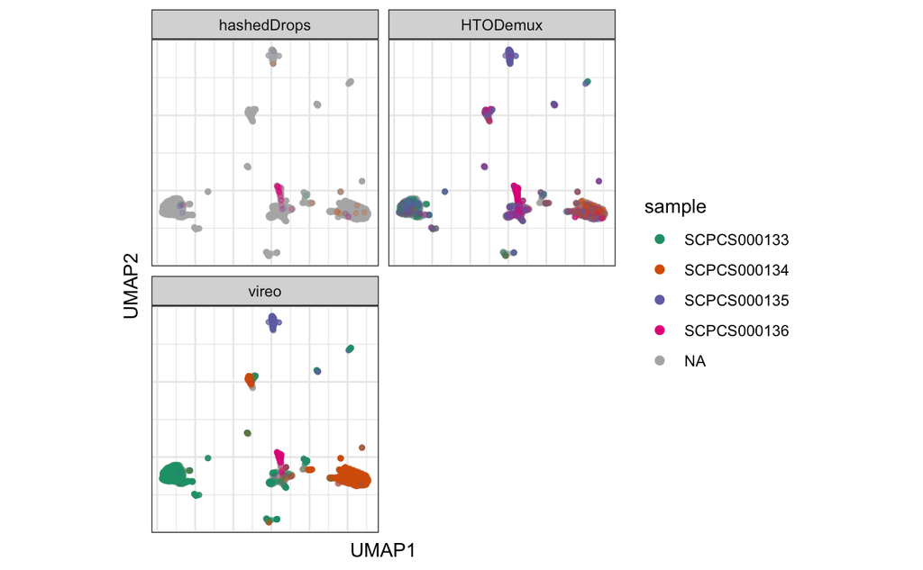

```r
ggplot(umap_plot_data, aes(x = UMAP1, y = UMAP2, color = sample)) +
  geom_point(size = 1, alpha = 0.2) +
  scale_color_brewer(palette = "Dark2", na.value = "grey70") +
  guides(color = guide_legend(override.aes = list(size = 2,
                                                  alpha = 1))) +
  facet_wrap("method", nrow = 2) +
  theme_bw() +
  theme(aspect.ratio = 1,
        axis.text = element_blank(),
        axis.ticks = element_blank())
```

Overall, it does look like the `vireo` results are most consistent with the overal structure of the data, and thus seem most likely to reflect the true sample identities. Of course, we do not know the true identities, and it is possible that the genetic demultiplexing is somehow conflating genetic and expression variation, but that seems less likely.

## Doublet calls

The demultiplexing methods can potentially identify doublets, where more than one cell of different types ended up in the same droplet. Here we will look at the overall rate of doublet calls for each method.

```r
# select doublet-related information for each method
demux_calls_doublet <- data.frame(
  hashedDrops_doublet = altExp(sce, "cellhash")$hashedDrops_Doublet,
  hashedDrops_conf = altExp(sce, "cellhash")$hashedDrops_Confident,
  HTODemux_class = altExp(sce, "cellhash")$HTODemux_classification.global,
  vireo_calls = sce$vireo_donor_id
)
demux_classes <- demux_calls_doublet |>
  dplyr::mutate( # make the _class calls match HTODemux classes
    hashedDrops_class = dplyr::case_when(
      hashedDrops_doublet ~ "Doublet",
      hashedDrops_conf ~ "Singlet",
      TRUE ~ "Negative"
    ),
    vireo_class = dplyr::case_when(
      vireo_calls == "doublet" ~ "Doublet",
      vireo_calls == "unassigned" ~ "Negative",
      is.na(vireo_calls) ~ "Negative",
      TRUE ~ "Singlet"
    )
  ) |>
  dplyr::select("hashedDrops_class", "HTODemux_class", "vireo_class") |>
  dplyr::mutate_all(as.factor)

summary(demux_classes)
```

```
 hashedDrops_class  HTODemux_class   vireo_class
 Doublet :   1     Doublet : 944   Doublet :  94
 Negative:8920     Negative:6048   Negative:3786
 Singlet :  42     Singlet :1971   Singlet :5083
```

Here we see that `HTODemux` seems to call the most doublets, which again makes sense if the cellhash background signal is substantial.

# Conclusions

The main challenge we see in this data is that there seems to be very high background in the cellhash/HTO signal in these data. The high background levels make it hard to pick out the sample-specific signal, so the HTO-based methods do not seem to perform very well.

`DropletUtils::hashedDrops` seems to be the most conservative method, and identifies very few cells overall.

`vireo`, which bases its calls on the genetic variants detected in each cell shows a stronger correspondence between sample calls and the expression variation, which makes sense if each sample is likely to have cells with distinct expression profiles. There are still clusters with cells from multiple samples, which also seems like it should be expected.

Overall, it remains unclear which if any of the methods is the most reliable, and attempting to answer that question is beyond the scope of this analysis, and indeed may be beyond the scope of this project as a whole. Rather than presenting a single set of calls as definitive and providing demultiplexed libraries for download, it seems like the best course of action is to allow downloading of the multiplexed library with all samples included, along with the calls and statistics generated by each of the demultiplexing methods. The task of deciding among the methods will be left to the end user, using the included statistics to allow for adjusting any thresholds and recalling cells as they deem fit. For the HTO-based methods, all of the count data will also be present to allow the application of other demultiplexing methods.